# California Rock Crab: Red Rock Crab Females

## Implementation Parameters

### TAC Implementation

#### Sampled Parameters

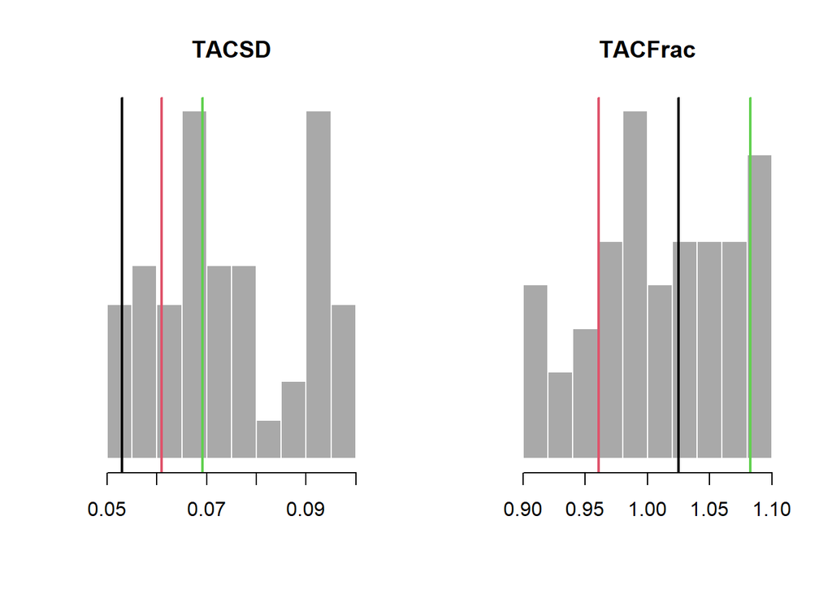

#### Time-Series

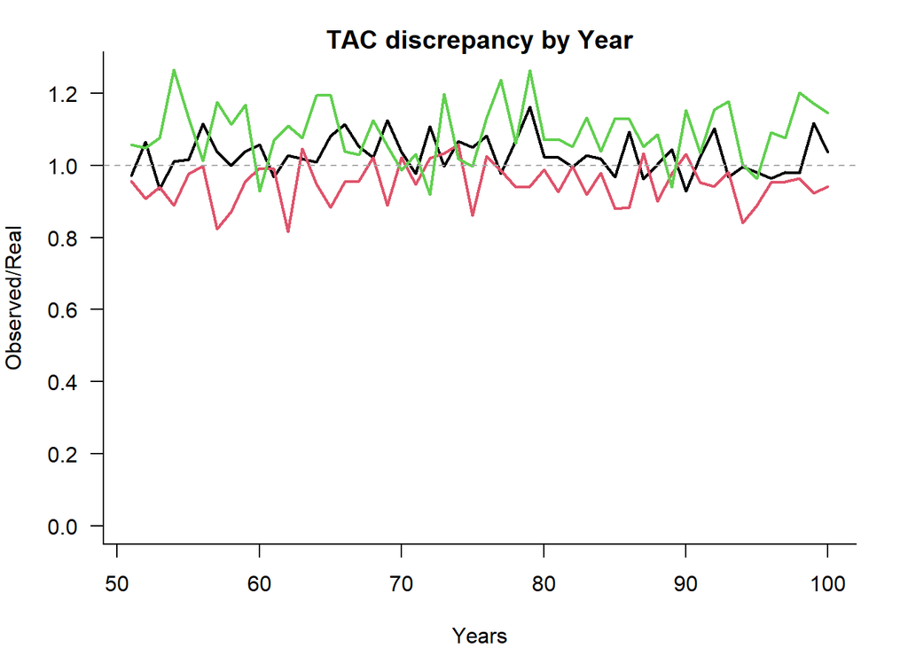

### TAE Implementation

#### Sampled Parameters

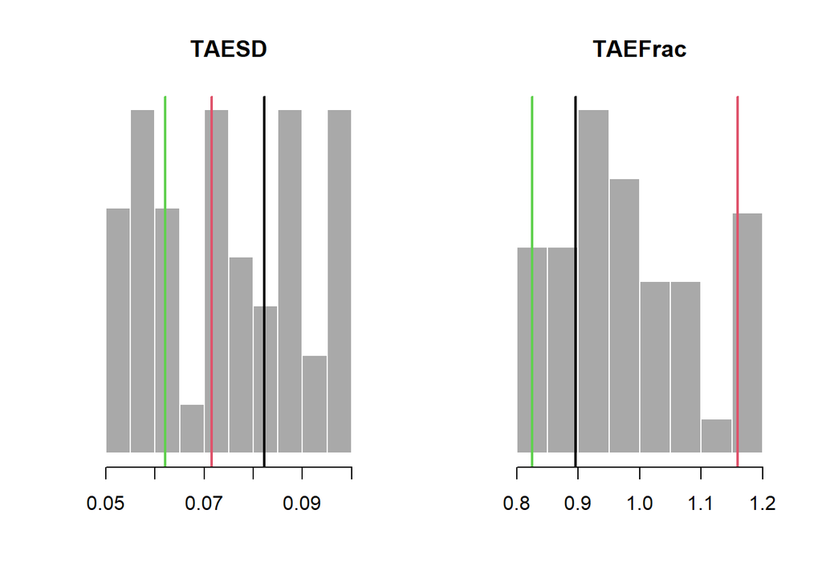

#### Time-Series

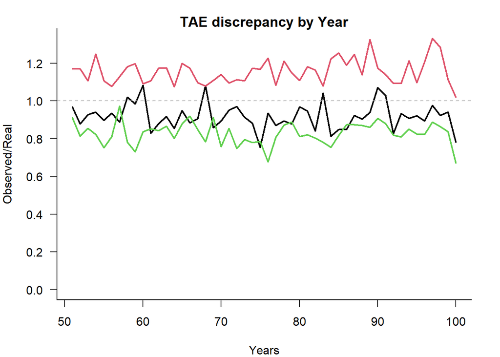

### Size Limit Implementation

#### Sampled Parameters

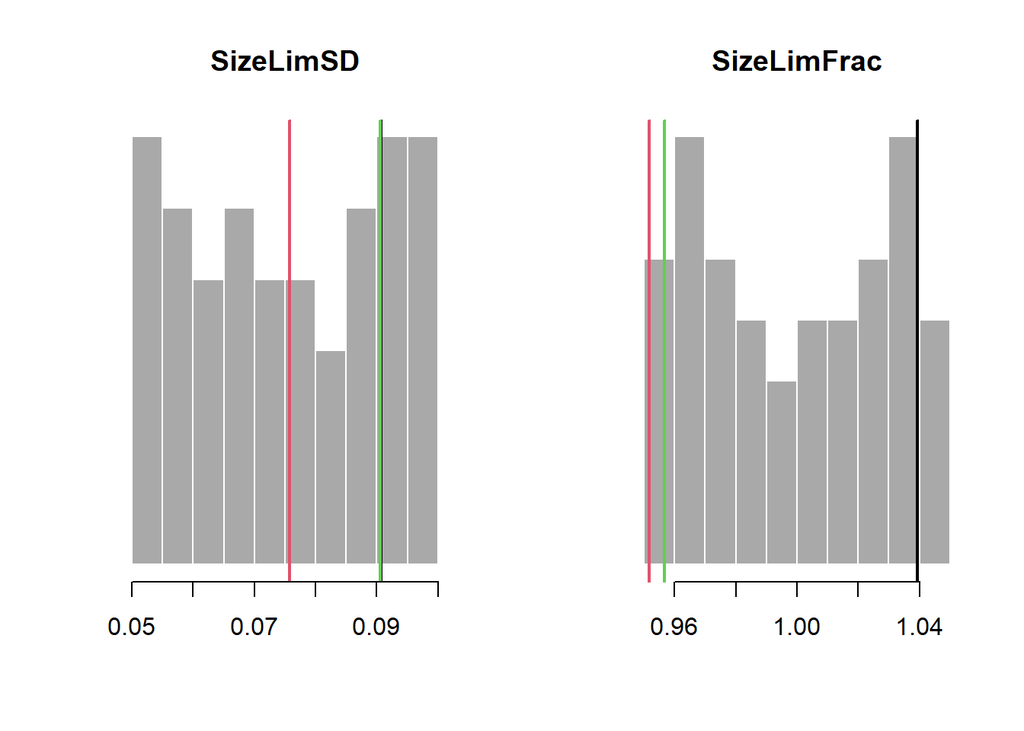

#### Time-Series

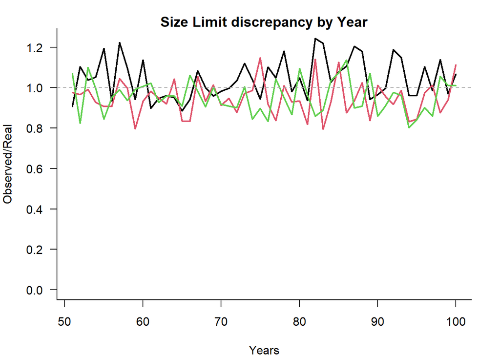

# Historical Simulation Plots

## Historical Time-Series

### Spawning Biomass

#### Depletion

Time-series plots of SB/SB0:

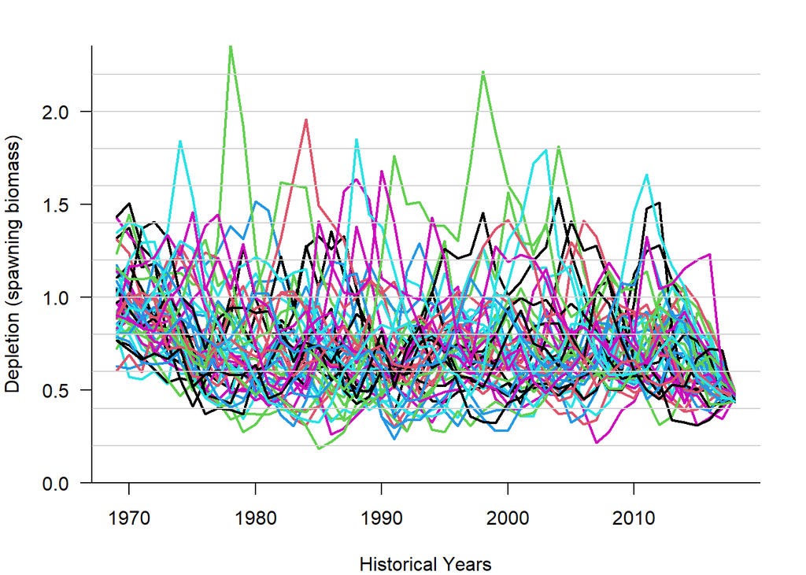

#### Absolute

Time-series plots of absolute SB:

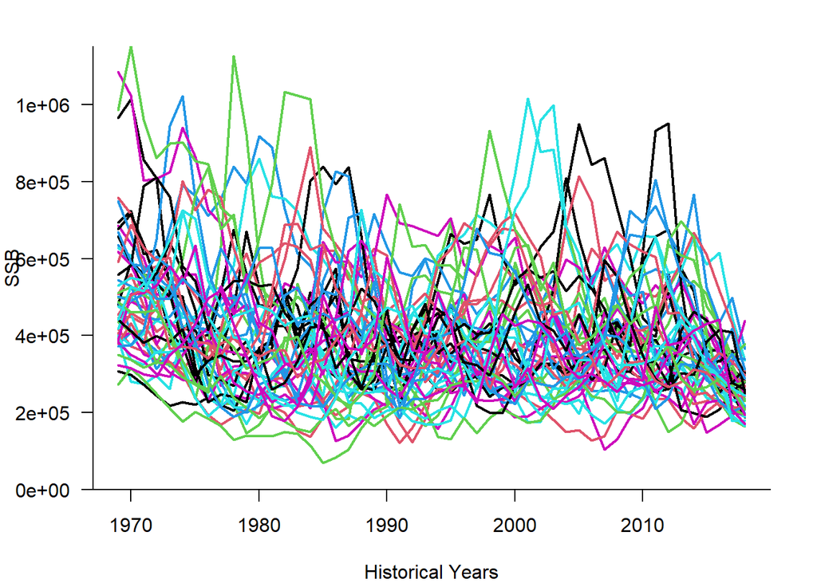

### Vulnerable Biomass

#### Depletion

Time-series plots of VB/VB0:

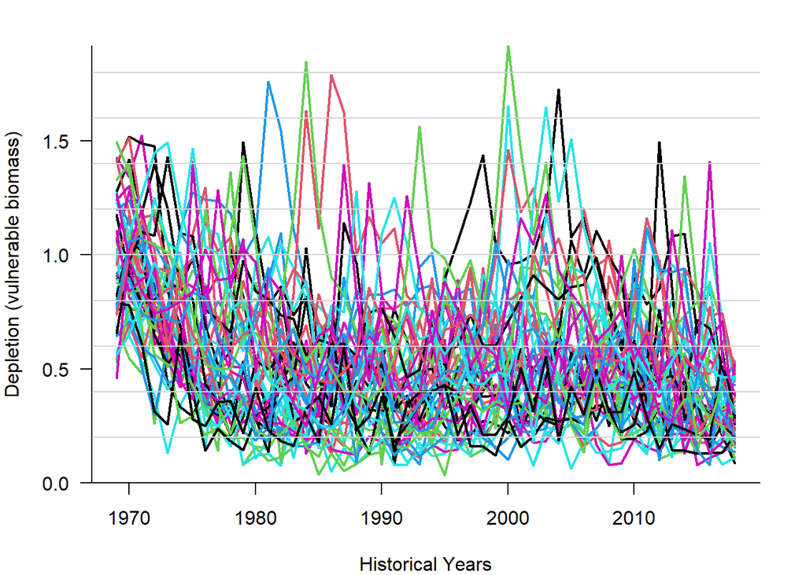

#### Absolute

Time-series plots of absolute VB:

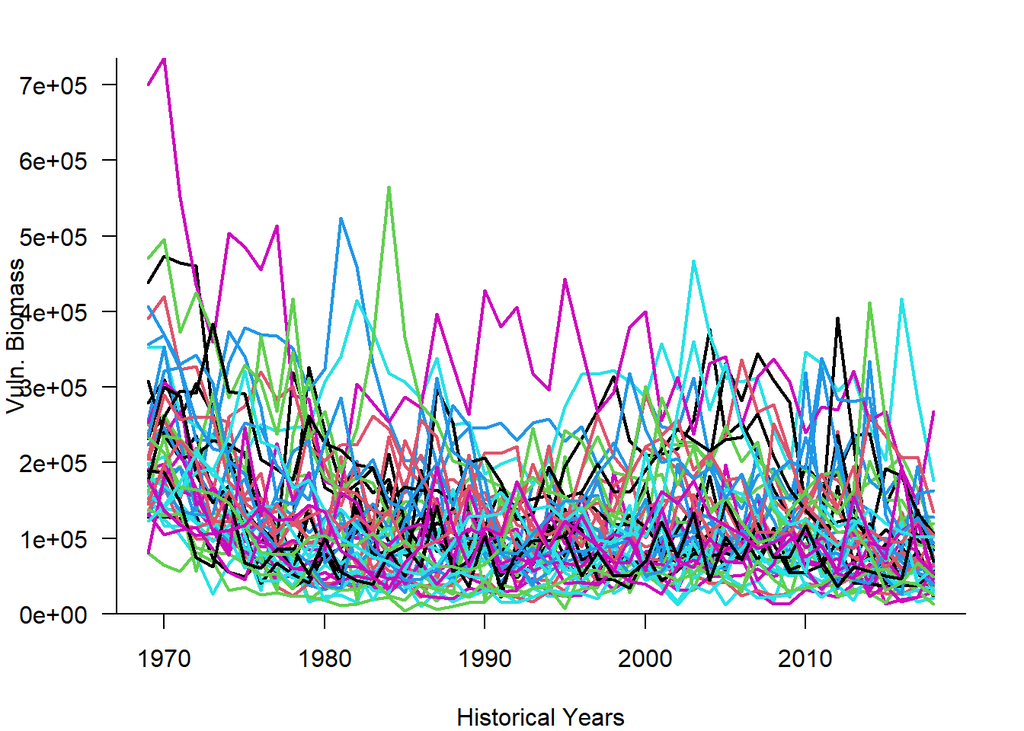

### Total Biomass

#### Depletion

Time-series plots of B/B0:

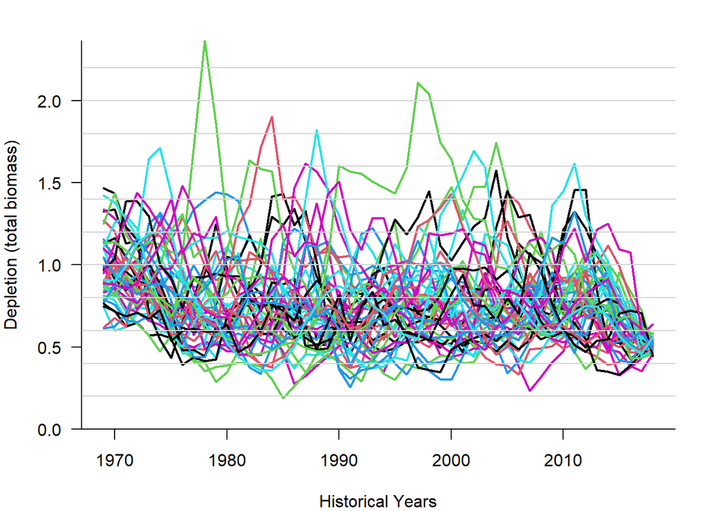

#### Absolute

Time-series plots of absolute B:

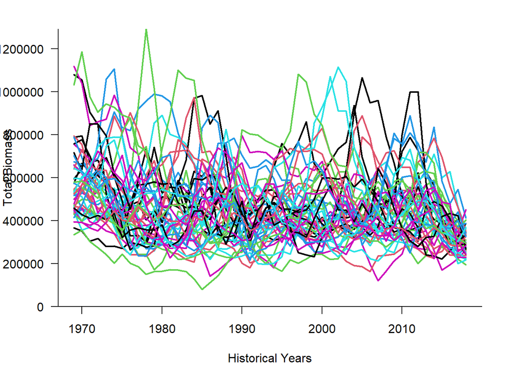

### Recruitment

#### Relative

Time-series plot of recruitment relative to R0:

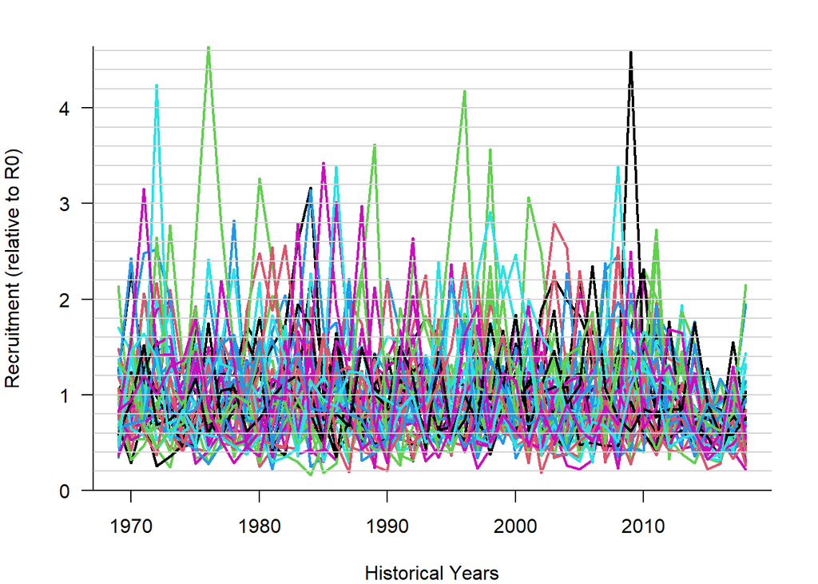

#### Absolute

Time-series plot of absolute recruitment:

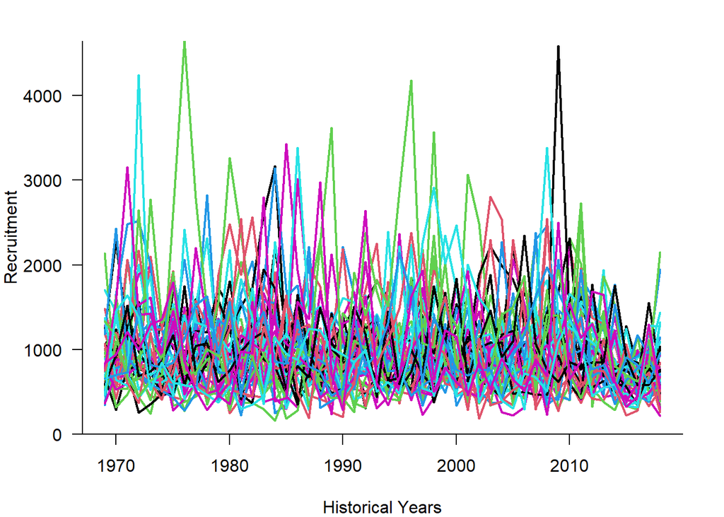

### Catch

#### Relative

Time-series of catch relative to the current year:

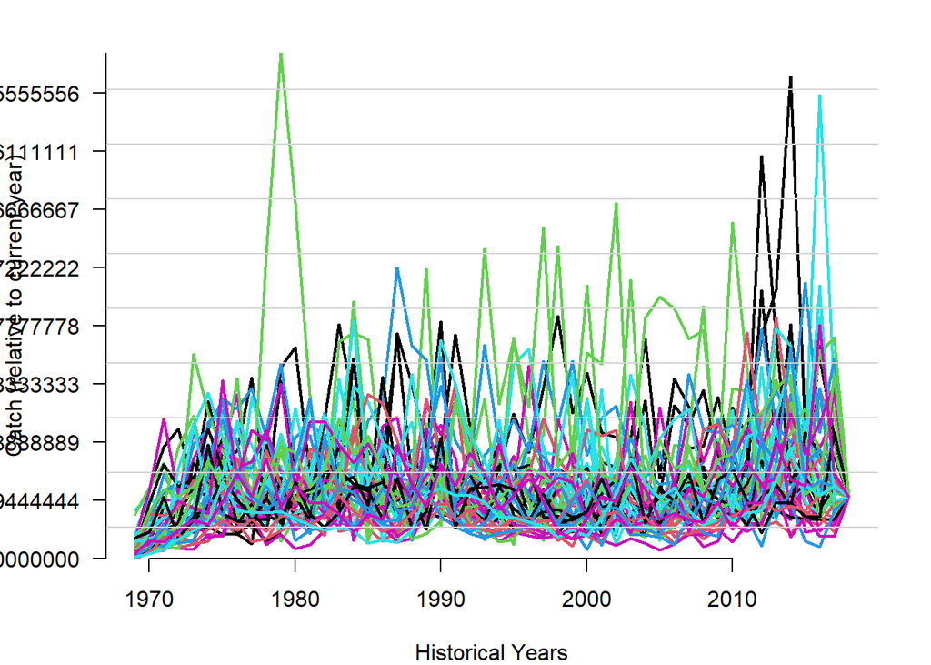

#### Absolute

Time-series of absolute catch:

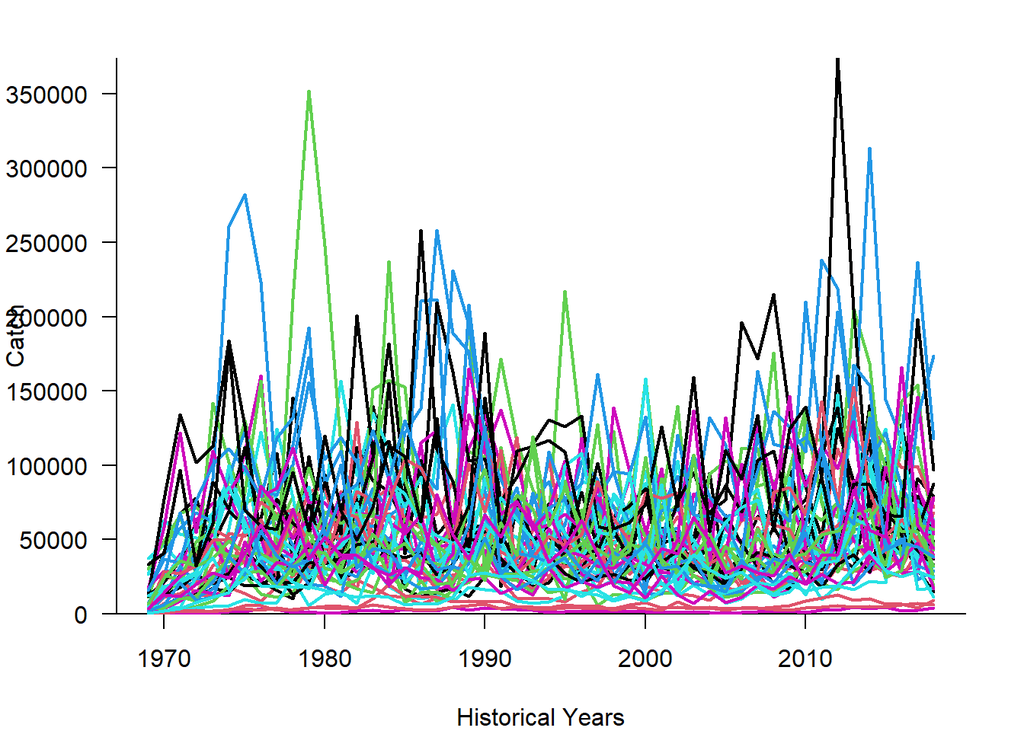

### Historical Fishing Mortality

#### Historical Time-Series

Time-series of historical fishing mortality:

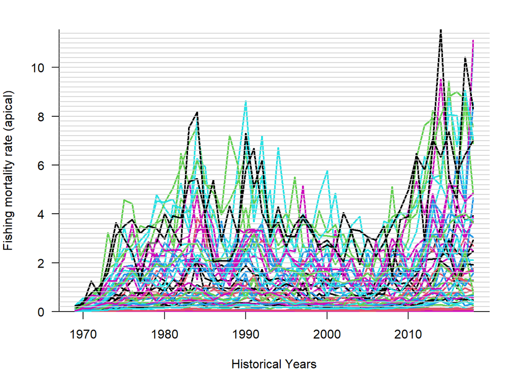

# References

California Department of Fish and Game (CDFG). 2003. Status of the Fisheries Report: An Update Through 2003. Chapter 5 Rock Crabs. 47 p.

Carroll C. 1982. Seasonal abundance, size composition, and growth of rock crab, Cancer antennarius Stimpson, off central California. Journal of Crustacean Biology 2(4): 549-561.

Culver CS, Schroeter SC, Page HM, Dugan JE. 2010. Essential Fishery Information for Trap-Based Fisheries: Development of a Framework for Collaborative Data Collection. Marine and Coastal Fisheries 2(1): 98-114.

Fitzgerald SP, Wilson JR, Lenihan HS. 2018. Detecting a need for improved management in a data-limited crab fishery. Fisheries research 1(208): 133-144.

Fitzgerald SP, Lenihan HS, Wilson JR, Culver CS, Potoski M. 2019. Collaborative research reveals cryptic declines within the multispecies California rock crab fishery. Fisheries Research. 220. https://doi.org/10.1016/j.fishres.2019.105340

Orensanz JM. and Gallucci VF. 1988. Comparative Study of Postlarval Life-History Schedules in Four Sympatric Species of Cancer (Decapoda: Brachyura: Cancridae). Journal of Crustacean Biology 8(2): 187.

Punt AE. and Methot RD. 2005. The impact of recruitment projection methods on forecasts of rebuilding rates for overfished marine resources. Pages 571-634 in Kruse GH, Gallucci VF, Hay DE , Perry RI, Peterman RM, Shirley TC, Spencer PD, Wilson B, Woodby D (eds), Fisheries Assessment in Data-Limited Situations. Alaska Sea Grant AK-SG-05-02.

Then AY, Hoenig JM, Hall NG, Hewitt DA. 2015. Evaluating the predictive performance of empirical estimators of natural mortality rate using information on over 200 fish species. ICES Journal of Marine Science. 72(1): 82-92.

Yamada SB, and Groth SD. 2016. Growth and longevity of the Red Rock crab Cancer productus (Randall 1840). Journal of shellfish research 35(4): 1045-1052.

Zheng J, Kruse G H, Gallucci V F, Hay D E, Perry R I, Peterman R M, Shirley T C, Spencer P D, et al. 2005. Review of natural mortality estimation for crab stocks: Data-limited for every stock?, Fisheries Assessment and Management in Data-Limited Situations, 2005 Alaska Sea Grant College Program, University of Alaska Fairbanks, AK-SG-05-02 (pg. 595-612) Proceedings of the Symposium Assessment and Management of New and Developed Fisheries in Data-Limited Situations, October 22-25, 2003, Anchorage, Alaska, USA 958 pp